# Práctica 2

Análisis de Componentes principales

12 de marzo de 2017

# 1 Introducción

Esta práctica consite un análisis de componentes principales de tres conjuntos de datos (**ventas**, **sctkp**, **dowjones**). En estadística, el **Análisis de Componentes Principales** (en español *ACP*, en inglés, *PCA*) es una técnica utilizada para reducir la dimensionalidad de un conjunto de datos.

Técnicamente, el ACP busca la proyección según la cual los datos queden mejor representados en términos de mínimos cuadrados. Convierte un conjunto de observaciones de variables, posiblemente correlacionadas, en un conjunto de valores de variables sin correlación lineal, llamadas componentes principales.

Los objetivos del Análisis de Componentes Principales son:

- Resumir la variación total en una **dimensión menor**.
- Identificar fuentes de variación **interpretables**.
- Explorar **características inesperadas** de los datos.

El ACP se emplea sobre todo en análisis exploratorio de datos y como herramienta de procesado inicial de los datos. El ACP comporta el cálculo de la descomposición en autovalores y autovectores de la matriz de covarianza, normalmente tras centrar los datos en la media de cada atributo. Las componentes principales están basadas en combinaciones lineales de los datos originales centrados $X-\bar{x}$

> Nota

Esta página web está escrita usando Markdown y es un [R Notebook](http://rmarkdown.rstudio.com). El notebook está creado con **R-Studio**, que utiliza *knitr* y *pandoc* para exportar el código a multiples formatos, entre ellos *.md*. Utilizando el botón *Code* situado en la parte superior derecha es posible descargar el archivo *.Rmd* y ejecutar los scripts mediante R-Studio desktop. Para ello es necesario tener instalados los paquetes:

```
install.packages("rmarkdown")
install.packages("installr")
install.packages("pandoc")
```

# 2 Carga de datos

En primer lugar, se carga el archivo **ventas.txt** a R-Studio. Para ello, debemos indicar previamente a R-Studio, cuál es el directorio de trabajo en el que estará localizado el archivo.

```r
ventas = read.table('ventas.txt')
show(ventas)
```

```
         ventas beneficios activos
G.M.       26.7        3.3    15.8
Exxon      38.4        2.4    19.5
Ford       19.2        1.7     8.4
Mobil      20.6        1.0     8.2
Texaco     18.9        0.9     9.4
Std.Oil    14.8        1.0     7.6
IBM        19.0        2.7    12.6
Gulf       14.2        0.8     7.3
G.E.       13.7        1.1     5.9
Chrysler    7.7        0.2     2.9
```

Para calcular el número de filas se puede emplear la función *“nrow”*.

```r
n = nrow(ventas)
print(c('número de filas=',n))
```

```
[1] "número de filas=" "10"
```

# 3 Descripción de los datos

Se crea el vector de **medias muestrales *m***, redondeando a cuatro decimales. El vector de medias muestrales, dada una matriz de datos $X_{n \times p} = (x_{ij})$, se calcula como:

$\bar{x} = \frac{1}{n} X^T 1_n = (\bar{x_j}:j=1,...,p)$

```r
m = round(colMeans(ventas), digits = 4);
round(m, digits = 4);
```

```
    ventas beneficios    activos
     19.32       1.51       9.76
```

y la matriz de **covarianzas muestrales *S*** , que se calcula como:

$S = \frac{1}{n} X^TX-\bar{x} \bar{x}^T = (s_{jk}:j=1,...,p)$

```r
S = cov(ventas);
round(S, digits = 4);
```

```
            ventas beneficios activos
ventas     70.4107     5.8731 39.0653
beneficios  5.8731     0.9699  4.1149
activos    39.0653     4.1149 24.0560
```

Se calcula la **Variación Total**, utilizando la función $VT = traza(S)$, en la que se suma la diagonal principal de la matriz de covarianzas muestrales,

```r
vt.ventas= round(sum(diag(S)), digits = 4)
vt.ventas
```

```
[1] 95.4366
```

Para el cálculo posterior de las variables tipificadas, se calcula la raiz de la diagonal principal de matriz de covarianzas,

```r
round(sqrt(diag(S)), digits = 4)
```

```
    ventas beneficios    activos
    8.3911     0.9848     4.9047
```

Ahora, se calcula la **matriz de correlación *R***, cuya diagonal principal será de unos. Si $D = diag(S)$ y $d = diag(D^{^-1/_2})$ entonces la matriz de correlaciones se calculá como:

$R = D^{^-1/_2}\times S \times D^{^-1/_2} = S \times dd^T = (r_{jk}=\frac{s_{jk}}{\sqrt{s_{jj}s_{kk}}})$

```r
R = cor(ventas);
round(R, digits = 4)
```

```
           ventas beneficios activos
ventas     1.0000     0.7107  0.9492
beneficios 0.7107     1.0000  0.8519
activos    0.9492     0.8519  1.0000
```

```r
round(c(min(R),max(R - diag(ncol(ventas)))), digits = 4);
```

```
[1] 0.7107 0.9492
```

## 3.1 Gráfico

Finalmente, en este apartado de descripción de los datos se genera un gráfico de tipo **Matriz de Nube Puntos** o *scatter plot matrix* usando la función *“plot”* con unos determinados parámetros opcionales para configurar la salida gráfica.

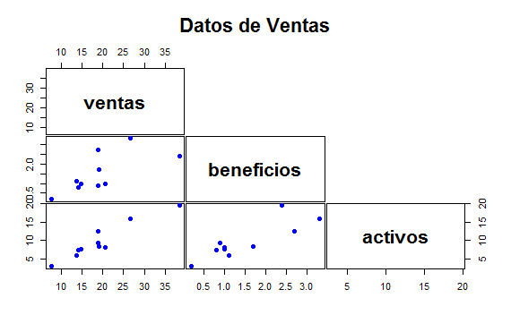

```r
plot(ventas,pch = 19,cex = 1,upper.panel = NULL,col = 'blue',
main = 'Datos de Ventas',cex.main = 1.4,gap = .15,cex.labels = 2,font.labels = 2)
```

# 4 Componentes principales

El software R-Studio incluye en el paquete *stats* la función *“princomp”*, utilizado para el análisis de componentes principales. Toma como argumento la matriz de datos y devuelve un vector de, al menos, siete elementos como respuesta:

| Elemento | Descripción |
| --- | --- |
| $sdev | Las desviaciones estándar de las componentes principales. |
| $loadings | Matiz de autovectores y matriz de proporciones |
| $center | Los valores medios que se restaron |
| $scale | Las escalas aplicadas a cada variable |
| $n.obs | El número de observaciones |
| $scores | Matriz de componentes principales (si es calculable) |
| $call | Llamada al nombre de la matriz de datos |

Puede consultarse la ayuda de esta función usando:

```
help("princomp")
```

Utilizando esta función sobre la matriz original de datos, se obtiene el vector de **componentes principales**, y haciendo que muestre todos los elementos de la respuesta,

```r
pc = princomp(ventas)
pc[1:7]
```

```
$sdev
   Comp.1    Comp.2    Comp.3
9.1590678 1.3675840 0.3661852

$loadings

Loadings:
           Comp.1 Comp.2 Comp.3
ventas      0.866  0.485 -0.122
beneficios        -0.372 -0.925
activos     0.494 -0.792  0.359

               Comp.1 Comp.2 Comp.3
SS loadings     1.000  1.000  1.000
Proportion Var  0.333  0.333  0.333
Cumulative Var  0.333  0.667  1.000

$center
    ventas beneficios    activos
     19.32       1.51       9.76

$scale
    ventas beneficios    activos
         1          1          1

$n.obs
[1] 10

$scores
              Comp.1     Comp.2      Comp.3
G.M.       9.5129590 -1.8714091 -0.38928000
Exxon     21.4042517  1.2035355  0.34001642
Ford      -0.7609231  0.9480711 -0.64981325
Mobil      0.2988297  2.0451158 -0.24556489
Texaco    -0.5886351  0.3082677  0.48639468
Std.Oil   -5.0209125 -0.2906013  0.24917581
IBM        1.2172603 -2.8461707 -0.04110956
Gulf      -5.7041718 -0.2694851  0.39987677
G.E.      -6.8054807  0.4852114 -0.31953403
Chrysler -13.5531775  0.2874647  0.16983805

$call
princomp(x = ventas)
```

Para el cálculo de **varianzas *var*** ($\sigma^2$) puede utilizarse el resultado de las desviaciones estandard anterior, indicando el nombre del elemnto que contiene ($\sigma$) y elevarlo al cuadrado, de la siguiente forma:

```r
var = with(pc, sdev^2)
round(var, digits = 4)
```

```
 Comp.1  Comp.2  Comp.3
83.8885  1.8703  0.1341
```

A continuación, se genera la variable *sc* para utilizarlo en Análisis equivalentes, si se sustituye $S_c = \frac{n}{n-1}*S$ cuasi-varianzas.

```r
sc = 1 - (1/n)
```

De forma que la varianza equivalente y, por tanto, los **Autovalores *var.eq*** ($L_{p \times 1}$) son:

```r
var.eq = (1/sc)*var
round(var.eq, digits = 4)
```

```
 Comp.1  Comp.2  Comp.3
93.2095  2.0781  0.1490
```

Para calcular los coeficientes de los **Autovectores *G*** ($G = (g_1,g_2,...,g_p)$) (transpuesta),

```r
G = with(pc, loadings)[,]
round(G, digits = 4)
```

```
           Comp.1  Comp.2  Comp.3
ventas     0.8661  0.4846 -0.1225
beneficios 0.0772 -0.3717 -0.9251
activos    0.4939 -0.7918  0.3594
```

Y para obtener la **matriz de componentes principales *scores***:

$Y = (X - 1_n \bar{x}^T)\times G$,

```r
scores = data.frame(with(pc, scores));
show(scores)
```

```
              Comp.1     Comp.2      Comp.3
G.M.       9.5129590 -1.8714091 -0.38928000
Exxon     21.4042517  1.2035355  0.34001642
Ford      -0.7609231  0.9480711 -0.64981325
Mobil      0.2988297  2.0451158 -0.24556489
Texaco    -0.5886351  0.3082677  0.48639468
Std.Oil   -5.0209125 -0.2906013  0.24917581
IBM        1.2172603 -2.8461707 -0.04110956
Gulf      -5.7041718 -0.2694851  0.39987677
G.E.      -6.8054807  0.4852114 -0.31953403
Chrysler -13.5531775  0.2874647  0.16983805
```

Es necesario cambiar el signo, tanto de los elementos de *G* como de *scores*. Por ejemplo, para la primera componente:

```r
G[,1] = -G[,1];
round(G[,1], digits =  4)
```

```
    ventas beneficios    activos
   -0.8661    -0.0772    -0.4939
```

```r
scores[,1] = -scores[,1]
round(scores[,1], digits =  4)
```

```
 [1]  -9.5130 -21.4043   0.7609  -0.2988   0.5886   5.0209  -1.2173
 [8]   5.7042   6.8055  13.5532
```

El siguiente paso será comprobar que la matriz de componentes principales cumple con las propiedades del teorema,

- El vector de **medias muestrales *m.cp*** ($\bar{y}$) es igual a cero.
- La matriz de **covarianzas muestrales *S.cp*** ($S_y$) tiene como diagonal el vector de autovalores.
- Las componentes son **incorreladas** de **media cero** y **decreciente de variabiliad**.

```r
m.cp = round(colMeans(scores), digits = 4)
m.cp
```

```
Comp.1 Comp.2 Comp.3
     0      0      0
```

```r
S.cp= round(cov(scores), digits =  4)
S.cp
```

```
        Comp.1 Comp.2 Comp.3
Comp.1 93.2095 0.0000  0.000
Comp.2  0.0000 2.0781  0.000
Comp.3  0.0000 0.0000  0.149
```

Otra comprobación a realizar sobre la matriz de componentes principales es, calcular la **Variación Total *VT.cp***, que también debe coincidir con la VT de los datos:

```r
VT.cp = round(sum(diag(cov(scores))),digits = 4)
VT.cp
```

```
[1] 95.4366
```

## 4.1 Gráfico Scatter plot

Se genera, como en el apartado anterior, un gráfico de Matriz de nube puntos *(scatter plot matrix)*. Para ello, en primer lugar se extrae una variable *r* que es la dimensión de la matriz de componentes principales, y en segundo lugar se definen los parámetros de la función *plot* con las caracteristicas de la salida gráfica.

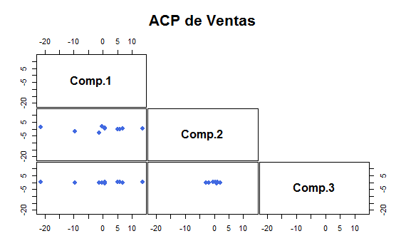

```r
r = with(scores, range(Comp.1));
plot(scores, pch = 19, cex = 1.2, upper.panel = NULL, col = 'royalblue', main = 'ACP de Ventas', cex.main = 1.3,xlim = r,
ylim = r,gap = .15,cex.labels = 1.5,font.labels = 2)
```

En el gráfico puede observarse como prácticamente todos los valores se encuentran sobre una línea horizontal.

## 4.2 Gráfico de coordenadas esféricas

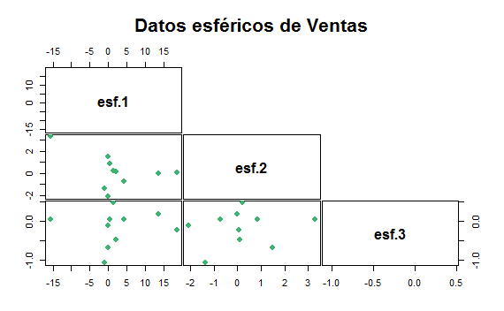

```r
plot(scores/sqrt(var), pch = 19,cex = 1.2, upper.panel = NULL, col = 'mediumseagreen', main = 'Datos esféricos de Ventas',labels = paste0('esf.',c(1:5)),cex.main = 1.3, gap = .15,cex.labels = 1.5,
font.labels = 2)
```

# 5 Reducción de la dimensión

En este apartado se trabaja en el objetivo inicial del ACP, la reducción de la dimensión para realizar un resumen de los datos.

En primer lugar, se calcula la proporción de variación y proporción acumulada, mostrándose luego en una única matriz de variación explicada.

```r
prop = S.cp/VT.cp;
acum = cumsum(prop)
table = round(data.frame(S.cp,prop,acum, row.names =NULL ),digits = 4)
cat('', sep = '\n');
```

**Proporciones**

```r
prop
```

```
          Comp.1     Comp.2      Comp.3
Comp.1 0.9766641 0.00000000 0.000000000
Comp.2 0.0000000 0.02177467 0.000000000
Comp.3 0.0000000 0.00000000 0.001561246
```

**Proporciones acumuladas**

```r
acum
```

```
[1] 0.9766641 0.9766641 0.9766641 0.9766641 0.9984388 0.9984388
[7] 0.9984388 0.9984388 1.0000000
```

**Matriz de proporción explicada**

```r
show(table)
```

```
   Comp.1 Comp.2 Comp.3 Comp.1.1 Comp.2.1 Comp.3.1   acum
1 93.2095 0.0000  0.000   0.9767   0.0000   0.0000 0.9767
2  0.0000 2.0781  0.000   0.0000   0.0218   0.0000 0.9767
3  0.0000 0.0000  0.149   0.0000   0.0000   0.0016 0.9767
4 93.2095 0.0000  0.000   0.9767   0.0000   0.0000 0.9767
5  0.0000 2.0781  0.000   0.0000   0.0218   0.0000 0.9984
6  0.0000 0.0000  0.149   0.0000   0.0000   0.0016 0.9984
7 93.2095 0.0000  0.000   0.9767   0.0000   0.0000 0.9984
8  0.0000 2.0781  0.000   0.0000   0.0218   0.0000 0.9984
9  0.0000 0.0000  0.149   0.0000   0.0000   0.0016 1.0000
```

## 5.1 Gráfico de pendiente (Screen plot)

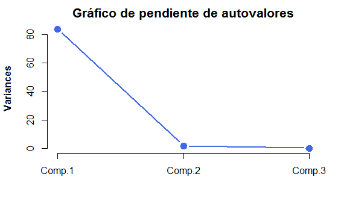

```r
plot(pc, type = 'l', col = 'royalblue',
pch = 19, lwd = 2.5, cex = 1.5,
main = 'Gráfico de pendiente de autovalores',
font.lab = 2,
cex.main = 1.3)
```

La **reducción de la dimensión** sería de $q = 1$, ya que $Y1$ explica el 97,67% de la variación.

# 6 Interpretación del análisis

$\frac{X1+X2+X3}{3}$

**1/3 normalizado:**

```r
1/sqrt(3)
```

```
[1] 0.5773503
```

```r
cons = -colMeans(ventas) %*% G[,1];
colnames(cons) = 'cons';
cat('', sep = '\n'); round(cons[,], d = 4);
```

```
   cons
21.6698
```

```r
cat('', sep = '\n');
```

```r
mat<-data.frame(pc.1 = round((1/sqrt(3))*(scores[,1] - cons), digits = 4), n.media = rowMeans(ventas))
cat('', sep = '\n');
```

```r
round(G[,2], digits = 4)
```

```
    ventas beneficios    activos
    0.4846    -0.3717    -0.7918
```

```r
show(mat)
```

```
             pc.1   n.media
G.M.     -18.0034 15.266667
Exxon    -24.8688 20.100000
Ford     -12.0718  9.766667
Mobil    -12.6836  9.933333
Texaco   -12.1712  9.733333
Std.Oil   -9.6123  7.800000
IBM      -13.2139 11.433333
Gulf      -9.2178  7.433333
G.E.      -8.5819  6.900000
Chrysler  -4.6862  3.600000
```

```r
round(G[,3], digits = 4)
```

```
    ventas beneficios    activos
   -0.1225    -0.9251     0.3594
```

> **Conclusión**: Conservar únicamente Y1

```r
cat('', sep = '\n'); round(cor(data.frame(ventas,scores[,1:2]))[1:3,1:3], digits = 4)
```

```
           ventas beneficios activos
ventas     1.0000     0.7107  0.9492
beneficios 0.7107     1.0000  0.8519
activos    0.9492     0.8519  1.0000
```

## 6.1 Gráfico ACP

Diseño del gráfico

```r
plot(scores, pch = 19,
col = 'mediumseagreen', cex = 1.4,
xlim = r, ylim = r);
#lineas de referencia
abline(h = 0, v = 0, lty = '1373', col = 'black',lwd = 1);
```

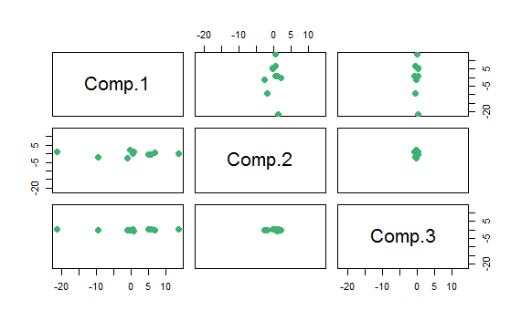

```r
#identificar individuos
lab = c(1:n);
text(scores, labels = lab, font = 2, col = 'navy',cex = 1.5, pos = 1)
```

Creación del gráfico final

```r
#seleccionar individuos
lab.plot = rep('',n);
lab.plot[1] = 'Std.1   '
lab.plot[c(2,28,66,81)] = paste0('Std.',c(2,28,66,81));
# vectorizar cex, pch, col, y pos
cex.plot = rep(1.4,n);
cex.plot[c(1,2,28,66,81)] = 1.6;
pch.plot = rep(19,n);
pch.plot[c(1,2,28,66,81)] = 15;
col.plot = rep('mediumseagreen',n);
col.plot[c(1,2,28,66,81)] = 'orangered';
pos.plot = rep(1,n);
pos.plot[1] = 3;
plot(scores, pch = pch.plot, col = col.plot, cex = cex.plot, xlim = r, ylim = r, col.lab = 'royalblue', font.lab = 2, cex.lab = 1.2)  ;
#box(lwd = 2);
#  líneas de referencia
abline(h = 0, v = 0, lty = '1373', col = 'brown',lwd = 2)
```

```r
points(.0,.0,pch = 16, cex = 1.2, col = 'firebrick1')
# identificar individuos
text(scores, labels = lab.plot, font = 2, col = 'navy', cex = 1., pos = pos.plot)
```

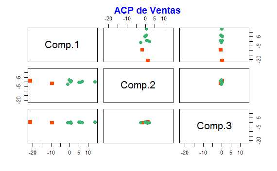

```r
title('ACP de Ventas', col.main = 'Blue',cex.main = 1.2)
```

Integración de componentes

```r
cat('',sep = '\n'); round(G[,1:2], digits = 4);
```

```
            Comp.1  Comp.2
ventas     -0.8661  0.4846
beneficios -0.0772 -0.3717
activos    -0.4939 -0.7918
```

```r
cat('',sep = '\n'); ventas[c(1,2), ]
```

|  | ventas | beneficios | activos |
| --- | --- | --- | --- |
| G.M. | 26.7 | 3.3 | 15.8 |
| Exxon | 38.4 | 2.4 | 19.5 |